# Chapter 2 - Import data and check for problems

# An introduction to R for Research (Ramzi W. Nahhas, 2025)

```r
# Import required packages
library(rmarkdown)
library(tidyverse)

library(readxl)
library(haven)
library(Hmisc)
library("matrixStats")
library(ie2misc)

# Check that all tidyverse packages are up-to-date
# tidyverse_update() # nolint
```

## Definitions

### Dataset

- It is structured in **rows** and **columns**, with one row per observation (e.g., person) and one column per variable (e.g., age, gender, height, weight)
- Datasets can be stored on a computer in various formats – a format for a specific program (e.g., Excel, R, SAS) or a structured Text file

### Required file structure for a statistical software

- One row per observation: longitudinal data (>1 row per person, but only 1 row/time/person)
- One column per variable
- Some consistent way of knowing when one variable ends and the next begins (fixed-width or delimited)
- If there are parts of the datafile with metadata (e.g., descriptions of the data, a codebook) or data summaries (e.g., column means), save a copy of the file with these removed before importing the data into R

```r
# Fixed-width files
# ?read.fwf
```

## Loading an R dataset

https://causeweb.org/tshs/arthritis-treatment/

```r
# Loading an R data file from a subfolder in the Project directory
load("data_Nahhas_2025/RheumArth_Tx_AgeComparisons.RData")

# Check the names of the file loaded
ls(RheumArth_Tx_AgeComparisons)
```

```
##  [1] "Age"           "AgeGp"         "Biologics"     "CDAI"
##  [5] "CDAI_YN"       "DAS_28"        "DAS28_YN"      "DMARDs"
##  [9] "ID"            "OsteopScreen"  "sDMARDS"       "Sex"
## [13] "Steroids_GT_5" "Yrs_From_Dx"
```

```r
# See the contents of the file
View(RheumArth_Tx_AgeComparisons)
is.data.frame(RheumArth_Tx_AgeComparisons)
```

```
## [1] TRUE
```

### Data dictionary (14 variables/features)

- **ID**: unique ID
- **Age**: age in years
- **AgeGp**: age group
- **Sex**: patient sex
- **Yrs_From_Dx**: years since diagnosis at the time of the study
- **CDAI**: “Clinical Disease Activity Indicator” value
- **CDAI_YN**: CDAI measured?
- **DAS_28**: “Disease activity score for 28 joints” value
- **DAS28_YN**: DAS_28 measured?
- **Steroids_GT_5**: patient on Steroids >5 mg/daily?
- **DMARDs**: patient receiving “Disease Modifying Anti-Rheumatic Drugs”?
- **Biologics**: patient receiving biologic agents?
- **sDMARDS**: patient receiving synthetic DMARDs?
- **OsteopScreen**: patient screened for osteoporosis?

### Tibble: a modern reimagining of the data.frame (lazy)

```r
# ?as_tibble # nolint
# as_tibble() : convert a data frame to a tibble

rheum_arth_tibble <- as_tibble(RheumArth_Tx_AgeComparisons)
rheum_arth_tibble
```

```
## # A tibble: 530 × 14
##       ID   Age AgeGp   Sex Yrs_From_Dx  CDAI CDAI_YN DAS_28 DAS28_YN
##    <int> <int> <int> <int>       <int> <dbl>   <int>  <dbl>    <int>
##  1     1    85     2     0          27  NA         1     NA        1
##  2     2    86     2     0          27  23         2     NA        1
##  3     3    83     2     0          10  14.5       2     NA        1
##  4     4    83     2     0           9  NA         1     NA        1
##  5     5    85     2     0          NA  NA         1     NA        1
##  6     6    79     2     1          NA  NA         1     NA        1
##  7     7    90     2     0          51  NA         1     NA        1
##  8     8    90     2     0          11  40         2     NA        1
##  9     9    87     2     0          36   6         2     NA        1
## 10    10    82     2     0           4  NA         1     NA        1
## # ℹ 520 more rows
## # ℹ 5 more variables: Steroids_GT_5 <int>, DMARDs <int>, Biologics <int>,
## #   sDMARDS <int>, OsteopScreen <int>
```

```r
# See all columns and their data types
# glimpse(rheum_arth_tibble) # nolint

# New tab : dataset in a spreadsheet view
View(rheum_arth_tibble)

# is_tibble() : test whether the object is a tibble
is_tibble(rheum_arth_tibble)
```

```
## [1] TRUE
```

```r
# class() : view the class of the object
class(rheum_arth_tibble)
```

```
## [1] "tbl_df"     "tbl"        "data.frame"
```

## Importing a file from another format (RStudio)

- While R is a programming language, RStudio does have some menu options
- Best practice is to import using code, not point-and-click => record what has been done
- Using “Import Dataset” is also a great way to explore the data before importing, to see if there are problems (e.g., a column with a mix of character and numeric data)

### Base R - Delimited .txt file - From Text (base)

**DO: File – Import Dataset – From Text (base)**

- Browse to where the file RheumArth.txt is saved. Select that file
- In the import dialog box:
- *Name*: name the dataset (default = name of the file)
- *Encoding*: change the Encoding (i.e., if the file is in a different language)
- *Heading*: set = Yes (if the variable names are in the first row)
- *Row names*: specify if there are row names (default = Automatic)
- *Separator*: specify the delimiter (separator)

**DO: Select some other delimiter options**

- See how the preview changes. Reset the delimiter to “Tab” before proceeding
- *Decimal*: specify the character for decimals
- *Quote*: specify if double, single, or no quotes
- *Comment*: specify if there is a character that designates a line as being a comment => skipped
- *na.strings*: specify which character designates missing data
- *Strings as factors*: how R handles a column with characters
  - *If left unchecked*: a column with ANY characters will be read in as a character variable
  - *If checked*: a column with ANY characters will be read in as a factor variable
  - *If unsure*: leave unchecked then convert variables that should be factors later in the code. It is easier to fix misspellings before converting to a factor

**DO: Import RheumArth.txt after setting Heading = Yes**

- The code appears in the console, and a dataset tab
- The code automatically displayed in the console may not be portable because of the way the path is specified
- The code below is portable

```r
# ?read.delim # nolint
# read.delim("file.txt") : read tabulation delimited file, period decimal marks
# read.delim2("file.txt") : read tabulation delimited file, comma decimal marks

# Import RheumArth.txt from the working directory
# Using read.delim with the default options

rheum_arth_txt_1 <- read.delim("data_Nahhas_2025/RheumArth_Tx_AgeComparisons.txt") # nolint
# rheum_arth_txt_1

View(rheum_arth_txt_1)
```

**DO: Re-import RheumArth.txt, but this time type a period (.) in na.strings**

- It is possible that none of the options will lead to a readable dataset
- In that case, do some detective work to figure out what is causing the problem
- Some extra rows (or columns) in the file that should not be there, or some unreadable characters

```r
# Import RheumArth.txt using read.delim with the na.strings option
# In the Import Dataset dialog, it is not possible to specify more than one
# missing data code, but it could be done by using code

rheum_arth_txt_2 <- read.delim("data_Nahhas_2025/RheumArth_Tx_AgeComparisons.txt", # nolint
  header = TRUE,              # default
  sep = "\t",                 # default is ","
  quote = "\"",               # default
  dec = ".",                  # default
  na.strings = c("", "NA"),   # default is "NA"
  skip = 0,                   # default
  fill = TRUE,                # default
  strip.white = TRUE,         # default is FALSE
  comment.char = "",          # default
  stringsAsFactors = FALSE,   # default
  encoding = "unknown"        # default
)
# rheum_arth_txt_2 # nolint

# See all columns and their data types
# glimpse(rheum_arth_txt_2) # nolint
# here, colClasses are the same as the tibble object

# New tab : dataset in a spreadsheet view
View(rheum_arth_txt_2)

# class() : view the class of the object
class(rheum_arth_txt_2)
```

```
## [1] "data.frame"
```

### Tidyverse - Delimited .txt file - From Text (readr)

- The base R function read.delim() has a tidyverse counterpart called read_delim()
- It is in the readr package (loaded automatically along with tidyverse)

**DO: File – Import Dataset – From Text (readr)**

- Click on “Browse” and navigate to where the file RheumArth.txt is saved. Select that file
- The Data Preview shows that the data have been read into a single variable
- In some cases, the default settings won’t work directly!

**Import Options**

- *Name*: name the dataset (default = name of the file)
- *Skip* (skip): how many rows to skip at the top of the file
- *First Row as Names* (col_names): check if the variable names are in the first row (better TRUE)
- *Trim Spaces* (trim_ws): check to trim off white space at the beginning and end of values (better TRUE)
- *Open Data Viewer*: check to run View() after importing to view the data in a data tab (better TRUE)
- *Delimiter* (delim): specify the delimiter to use (if none, it will automatically guess)
- *Quotes* (quote): default
- *Locale* (locale): opens a dialog where to specify various formats (date, time, marks, encoding)
- *Escape* (escape_backslash, escape_double): a character that tells R to read in the next character literally, not as a special character
- *Comment* (comment): specify if there is a character that designates a line as being a comment => skipped (better default)
- *NA* (na): specify what character designates missing data
- This procedure does NOT convert character data to factors!

**DO: Import RheumArth.txt with the name “RheumArth_tibble”, use Tab as the delimiter, and leave the other options at their default values**

```r
# ?read_delim # nolint
# read_delim("file.txt") : read any delimited file, period decimal marks

rheum_arth_txt_3_tibble <- read_delim("data_Nahhas_2025/RheumArth_Tx_AgeComparisons.txt", # nolint
  col_names = TRUE,         # default
  col_types = cols(
    "ID" = col_integer(),
    "Age" = col_integer(),
    "AgeGp" = col_integer(),
    "Sex" = col_integer(),
    "Yrs_From_Dx" = col_integer(),
    "CDAI" = col_double(),
    "CDAI_YN" = col_integer(),
    "DAS_28" = col_integer(),
    "DAS28_YN" = col_double(),
    "Steroids_GT_5" = col_integer(),
    "DMARDs" = col_integer(),
    "Biologics" = col_integer(),
    "sDMARDS" = col_integer(),
    "OsteopScreen" = col_integer(),
  ),
  delim = "\t",
  escape_double = FALSE,    # default is TRUE
  locale = locale(          # default
    date_names = "en",
    date_format = "%AD",
    time_format = "%AT",
    decimal_mark = ".",
    grouping_mark = ",",
    tz = "UTC",
    encoding = "UTF-8",
    asciify = FALSE
  ),
  na = c("", "NA"),         # default
  trim_ws = TRUE,           # default is FALSE
  skip = 0                  # default
)
rheum_arth_txt_3_tibble
```

```
## # A tibble: 530 × 14
##       ID   Age AgeGp   Sex Yrs_From_Dx  CDAI CDAI_YN DAS_28 DAS28_YN
##    <int> <int> <int> <int>       <int> <dbl>   <int>  <int>    <dbl>
##  1     1    85     2     0          27  NA         1     NA        1
##  2     2    86     2     0          27  23         2     NA        1
##  3     3    83     2     0          10  14.5       2     NA        1
##  4     4    83     2     0           9  NA         1     NA        1
##  5     5    85     2     0          NA  NA         1     NA        1
##  6     6    79     2     1          NA  NA         1     NA        1
##  7     7    90     2     0          51  NA         1     NA        1
##  8     8    90     2     0          11  40         2     NA        1
##  9     9    87     2     0          36   6         2     NA        1
## 10    10    82     2     0           4  NA         1     NA        1
## # ℹ 520 more rows
## # ℹ 5 more variables: Steroids_GT_5 <int>, DMARDs <int>, Biologics <int>,
## #   sDMARDS <int>, OsteopScreen <int>
```

```r
# See all columns and their data types
# glimpse(rheum_arth_txt_3_tibble) # nolint

# New tab : dataset in a spreadsheet view
View(rheum_arth_txt_3_tibble)

# is_tibble() : test whether the object is a tibble
is_tibble(rheum_arth_txt_3_tibble)
```

```
## [1] TRUE
```

```r
# class() : view the class of the object
class(rheum_arth_txt_3_tibble)
```

```
## [1] "spec_tbl_df" "tbl_df"      "tbl"         "data.frame"
```

### Base R - Comma delimited .csv file

- A **.csv** file is a special kind of text file, it is comma delimited
- *Encoding* (encoding)
- *Heading* (header)
- *Row names* (row.names)
- *Separator* (sep)
- *Decimal* (dec)
- *Quote* (quote)
- *Comment* (comment.char)
- *na.strings* (na.strings)
- *Strings as factors* (stringsAsFactors)

```r
# ?read.csv # nolint
# read.csv("file.csv") : read comma delimited file, period decimal marks
# read.csv2("file.csv") : read semi-colon delimited file, comma decimal marks

# Warning : .csv was saved from Excel in UTF-8 (comma delimited file)
# but returned a semi-colon delimited file

rheum_arth_csv <- read.csv("data_Nahhas_2025/RheumArth_Tx_AgeComparisons.csv", # nolint
  header = TRUE,              # default
  sep = ";",                  # default is ","
  quote = "\"",               # default
  dec = ".",                  # default
  na.strings = c("", "NA"),   # default is "NA"
  skip = 0,                   # default
  fill = TRUE,                # default
  strip.white = TRUE,         # default is FALSE
  comment.char = "",          # default
  stringsAsFactors = FALSE,   # default
  encoding = "unknown"        # default
)
# rheum_arth_csv # nolint

# See all columns and their data types
# glimpse(rheum_arth_csv) # nolint
# here, colClasses are the same as the tibble object

# New tab : dataset in a spreadsheet view
View(rheum_arth_csv)

# class() : view the class of the object
class(rheum_arth_csv)
```

```
## [1] "data.frame"
```

### Tidyverse - Comma delimited .csv file

```r
# ?read_csv # nolint
# read_csv("file.csv") : read comma delimited file, period decimal marks
# read_csv2("file.csv") : read semi-colon delimited file, comma decimal marks

rheum_arth_csv_tibble <- read_csv("data_Nahhas_2025/RheumArth_Tx_AgeComparisons.csv", # nolint
  col_names = TRUE,         # default
  # col_types = cols()      # nolint
  locale = locale(          # default
    date_names = "en",
    date_format = "%AD",
    time_format = "%AT",
    decimal_mark = ".",
    grouping_mark = ",",
    tz = "UTC",
    encoding = "UTF-8",
    asciify = FALSE
  ),
  na = c("", "NA"),         # default
  quote = "\"",             # default
  comment = "",             # default
  trim_ws = TRUE,           # default
  skip = 0                  # default
)
# DID NOT WORK HERE!
# Warning : .csv was saved from Excel in UTF-8 (comma delimited file)
# but returned a semi-colon delimited file
rheum_arth_csv_tibble
```

```
## # A tibble: 530 × 1
##    ID;Age;AgeGp;Sex;Yrs_From_Dx;CDAI;CDAI_YN;DAS_28;DAS28_YN;Steroids_GT_5;DMA…¹
##    <chr>
##  1 1;85;2;0;27;;1;;1;0;1;0;0;0
##  2 2;86;2;0;27;23;2;;1;1;1;0;0;1
##  3 3;83;2;0;10;14.5;2;;1;1;1;1;0;1
##  4 4;83;2;0;9;;1;;1;1;1;0;0;1
##  5 5;85;2;0;;;1;;1;0;0;0;0;0
##  6 6;79;2;1;;;1;;1;0;0;0;0;0
##  7 7;90;2;0;51;;1;;1;0;1;1;0;0
##  8 8;90;2;0;11;40;2;;1;1;0;0;0;1
##  9 9;87;2;0;36;6;2;;1;0;0;1;0;1
## 10 10;82;2;0;4;;1;;1;0;1;0;0;1
## # ℹ 520 more rows
## # ℹ abbreviated name:
## #   ¹`ID;Age;AgeGp;Sex;Yrs_From_Dx;CDAI;CDAI_YN;DAS_28;DAS28_YN;Steroids_GT_5;DMARDs;Biologics;sDMARDS;OsteopScreen`
```

```r
# See all columns and their data types
# glimpse(rheum_arth_csv_tibble) # nolint

# New tab : dataset in a spreadsheet view
View(rheum_arth_csv_tibble)

# is_tibble() : test whether the object is a tibble
is_tibble(rheum_arth_csv_tibble)
```

```
## [1] TRUE
```

```r
# class() : view the class of the object
class(rheum_arth_csv_tibble)
```

```
## [1] "spec_tbl_df" "tbl_df"      "tbl"         "data.frame"
```

### Base R with Tidyverse - Excel file (.xls, .xlsx)

**DO: File – Import Dataset – From Excel**

- Click on “Browse” at the upper right
- Navigate to where saved the file .xlsx was saved
- Select that file

**Import Options**

- *Name*: name the dataset (default = name of the file)
- *Sheet* (sheet): R can only read in one worksheet at a time
- *Range* (range): only import data from a subset of the cells (to avoid metadata, summaries)
- *Max Rows* (n_max): stop after a certain number of rows
- *Skip* (skip): how many rows to skip at the top of the file
- *NA* (na): specify what character designates missing data
- *First Rows as Names* (col_names): check if the variable names are in the first row
- *Open Data Viewer* View(): check to run after import

```r
# ??read_excel # nolint
# read_excel("file.xls") : read a .xls or .xlsx file based on the file extension
# read_xls("file.xls") : read a .xls file based on the file extension
# read_xlsx("file.xlsx") : read a .xlsx file based on the file extension

# readxl is part of tidyverse, it will create a tibble
rheum_arth_xlsx_tibble <- read_xlsx("data_Nahhas_2025/RheumArth_Tx_AgeComparisons.xlsx", # nolint
  col_names = TRUE,         # default
  col_types = "numeric",
  sheet = "Data",
  na = c("", "NA"),         # default
  trim_ws = TRUE,           # default
  skip = 0                  # default
)
rheum_arth_xlsx_tibble
```

```
## # A tibble: 530 × 14
##       ID   Age AgeGp   Sex Yrs_From_Dx  CDAI CDAI_YN DAS_28 DAS28_YN
##    <dbl> <dbl> <dbl> <dbl>       <dbl> <dbl>   <dbl>  <dbl>    <dbl>
##  1     1    85     2     0          27  NA         1     NA        1
##  2     2    86     2     0          27  23         2     NA        1
##  3     3    83     2     0          10  14.5       2     NA        1
##  4     4    83     2     0           9  NA         1     NA        1
##  5     5    85     2     0          NA  NA         1     NA        1
##  6     6    79     2     1          NA  NA         1     NA        1
##  7     7    90     2     0          51  NA         1     NA        1
##  8     8    90     2     0          11  40         2     NA        1
##  9     9    87     2     0          36   6         2     NA        1
## 10    10    82     2     0           4  NA         1     NA        1
## # ℹ 520 more rows
## # ℹ 5 more variables: Steroids_GT_5 <dbl>, DMARDs <dbl>, Biologics <dbl>,
## #   sDMARDS <dbl>, OsteopScreen <dbl>
```

```r
# See all columns and their data types
# glimpse(rheum_arth_xlsx_tibble) # nolint

# New tab : dataset in a spreadsheet view
View(rheum_arth_xlsx_tibble)

# is_tibble() : test whether the object is a tibble
is_tibble(rheum_arth_xlsx_tibble)
```

```
## [1] TRUE
```

```r
# class() : view the class of the object
class(rheum_arth_xlsx_tibble)
```

```
## [1] "tbl_df"     "tbl"        "data.frame"
```

### SPSS file (.sav)

```r
# ?read_sav # nolint
# read_sav("file.sav") : read both .sav and .zsav files

rheum_arth_sav_tibble <- read_sav("data_Nahhas_2025/RheumArth_Tx_AgeComparisons.sav", # nolint
  user_na = FALSE           # default
)
rheum_arth_sav_tibble
```

```
## # A tibble: 530 × 14
##       ID   Age AgeGp           Sex     Yrs_From_Dx  CDAI CDAI_YN DAS_28 DAS28_YN
##    <dbl> <dbl> <dbl+lbl>       <dbl+l>       <dbl> <dbl> <dbl+l>  <dbl> <dbl+lb>
##  1     1    85 2 [75 and olde… 0 [Fem…          27  NA   1 [No]      NA 1 [No]
##  2     2    86 2 [75 and olde… 0 [Fem…          27  23   2 [Yes]     NA 1 [No]
##  3     3    83 2 [75 and olde… 0 [Fem…          10  14.5 2 [Yes]     NA 1 [No]
##  4     4    83 2 [75 and olde… 0 [Fem…           9  NA   1 [No]      NA 1 [No]
##  5     5    85 2 [75 and olde… 0 [Fem…          NA  NA   1 [No]      NA 1 [No]
##  6     6    79 2 [75 and olde… 1 [Mal…          NA  NA   1 [No]      NA 1 [No]
##  7     7    90 2 [75 and olde… 0 [Fem…          51  NA   1 [No]      NA 1 [No]
##  8     8    90 2 [75 and olde… 0 [Fem…          11  40   2 [Yes]     NA 1 [No]
##  9     9    87 2 [75 and olde… 0 [Fem…          36   6   2 [Yes]     NA 1 [No]
## 10    10    82 2 [75 and olde… 0 [Fem…           4  NA   1 [No]      NA 1 [No]
## # ℹ 520 more rows
## # ℹ 5 more variables: Steroids_GT_5 <dbl+lbl>, DMARDs <dbl+lbl>,
## #   Biologics <dbl+lbl>, sDMARDS <dbl+lbl>, OsteopScreen <dbl+lbl>
```

```r
# See all columns and their data types
# glimpse(rheum_arth_sav_tibble) # nolint
# here, most columns display a <dbl+lbl> (double + label) type

# New tab : dataset in a spreadsheet view
head(rheum_arth_sav_tibble) # to avoid node stack overflow
```

```
## # A tibble: 6 × 14
##      ID   Age AgeGp            Sex     Yrs_From_Dx  CDAI CDAI_YN DAS_28 DAS28_YN
##   <dbl> <dbl> <dbl+lbl>        <dbl+l>       <dbl> <dbl> <dbl+l>  <dbl> <dbl+lb>
## 1     1    85 2 [75 and older] 0 [Fem…          27  NA   1 [No]      NA 1 [No]
## 2     2    86 2 [75 and older] 0 [Fem…          27  23   2 [Yes]     NA 1 [No]
## 3     3    83 2 [75 and older] 0 [Fem…          10  14.5 2 [Yes]     NA 1 [No]
## 4     4    83 2 [75 and older] 0 [Fem…           9  NA   1 [No]      NA 1 [No]
## 5     5    85 2 [75 and older] 0 [Fem…          NA  NA   1 [No]      NA 1 [No]
## 6     6    79 2 [75 and older] 1 [Mal…          NA  NA   1 [No]      NA 1 [No]
## # ℹ 5 more variables: Steroids_GT_5 <dbl+lbl>, DMARDs <dbl+lbl>,
## #   Biologics <dbl+lbl>, sDMARDS <dbl+lbl>, OsteopScreen <dbl+lbl>
```

```r
# is_tibble() : test whether the object is a tibble
is_tibble(rheum_arth_sav_tibble)
```

```
## [1] TRUE
```

```r
# class() : view the class of the object
class(rheum_arth_sav_tibble)
```

```
## [1] "tbl_df"     "tbl"        "data.frame"
```

### SAS file (.sas7bdat)

```r
# ?read_sas # nolint
# read_sas("file.sas7bcat") : supports both sas7bdat files
# and the accompanying sas7bcat files that SAS uses to record value labels

rheum_arth_sas_tibble <- read_sas("data_Nahhas_2025/RheumArth_Tx_AgeComparisons.sas7bdat", # nolint
  skip = 0L                 # default
)
rheum_arth_sas_tibble
```

```
## # A tibble: 530 × 14
##       ID   Age AgeGp   Sex Yrs_From_Dx  CDAI CDAI_YN DAS_28 DAS28_YN
##    <dbl> <dbl> <dbl> <dbl>       <dbl> <dbl>   <dbl>  <dbl>    <dbl>
##  1     1    85     2     0          27  NA         1     NA        1
##  2     2    86     2     0          27  23         2     NA        1
##  3     3    83     2     0          10  14.5       2     NA        1
##  4     4    83     2     0           9  NA         1     NA        1
##  5     5    85     2     0          NA  NA         1     NA        1
##  6     6    79     2     1          NA  NA         1     NA        1
##  7     7    90     2     0          51  NA         1     NA        1
##  8     8    90     2     0          11  40         2     NA        1
##  9     9    87     2     0          36   6         2     NA        1
## 10    10    82     2     0           4  NA         1     NA        1
## # ℹ 520 more rows
## # ℹ 5 more variables: Steroids_GT_5 <dbl>, DMARDs <dbl>, Biologics <dbl>,
## #   sDMARDS <dbl>, OsteopScreen <dbl>
```

```r
# See all columns and their data types
# glimpse(rheum_arth_sas_tibble) # nolint
# here, most columns display a <dbl+lbl> (double + label) type

# New tab : dataset in a spreadsheet view
View(rheum_arth_sas_tibble)

# is_tibble() : test whether the object is a tibble
is_tibble(rheum_arth_sas_tibble)
```

```
## [1] TRUE
```

```r
# class() : view the class of the object
class(rheum_arth_sas_tibble)
```

```
## [1] "tbl_df"     "tbl"        "data.frame"
```

### Stata file (.dta)

```r
# ?read_dta # nolint
# read_dta ("file.dta") : read .dta files

rheum_arth_dta_tibble <- read_dta("data_Nahhas_2025/RheumArth_Tx_AgeComparisons.dta", # nolint
  skip = 0                  # default
)
rheum_arth_dta_tibble
```

```
## # A tibble: 530 × 14
##       id   Age AgeGp   Sex Yrs_From_Dx  cdai CDAI_YN DAS_28 DAS28_YN
##    <dbl> <dbl> <dbl> <dbl>       <dbl> <dbl>   <dbl>  <dbl>    <dbl>
##  1     1    85     2     0          27  NA         1     NA        1
##  2     2    86     2     0          27  23         2     NA        1
##  3     3    83     2     0          10  14.5       2     NA        1
##  4     4    83     2     0           9  NA         1     NA        1
##  5     5    85     2     0          NA  NA         1     NA        1
##  6     6    79     2     1          NA  NA         1     NA        1
##  7     7    90     2     0          51  NA         1     NA        1
##  8     8    90     2     0          11  40         2     NA        1
##  9     9    87     2     0          36   6         2     NA        1
## 10    10    82     2     0           4  NA         1     NA        1
## # ℹ 520 more rows
## # ℹ 5 more variables: Steroids_GT_5 <dbl>, DMARDs <dbl>, Biologics <dbl>,
## #   sDMARDS <dbl>, OsteopScreen <dbl>
```

```r
# See all columns and their data types
# glimpse(rheum_arth_dta_tibble) # nolint
# here, all columns correspond to the numeric type

# New tab : dataset in a spreadsheet view
View(rheum_arth_dta_tibble)

# is_tibble() : test whether the object is a tibble
is_tibble(rheum_arth_dta_tibble)
```

```
## [1] TRUE
```

```r
# class() : view the class of the object
class(rheum_arth_dta_tibble)
```

```
## [1] "tbl_df"     "tbl"        "data.frame"
```

## Converting between base R (data.frame) and tidyverse (tibble)

**Convert data.frame to tibble**

```r
# ?as_tibble # nolint
# as_tibble() : convert a data frame to a tibble

rheum_arth_tibble <- as_tibble(RheumArth_Tx_AgeComparisons)
rheum_arth_tibble
```

```
## # A tibble: 530 × 14
##       ID   Age AgeGp   Sex Yrs_From_Dx  CDAI CDAI_YN DAS_28 DAS28_YN
##    <int> <int> <int> <int>       <int> <dbl>   <int>  <dbl>    <int>
##  1     1    85     2     0          27  NA         1     NA        1
##  2     2    86     2     0          27  23         2     NA        1
##  3     3    83     2     0          10  14.5       2     NA        1
##  4     4    83     2     0           9  NA         1     NA        1
##  5     5    85     2     0          NA  NA         1     NA        1
##  6     6    79     2     1          NA  NA         1     NA        1
##  7     7    90     2     0          51  NA         1     NA        1
##  8     8    90     2     0          11  40         2     NA        1
##  9     9    87     2     0          36   6         2     NA        1
## 10    10    82     2     0           4  NA         1     NA        1
## # ℹ 520 more rows
## # ℹ 5 more variables: Steroids_GT_5 <int>, DMARDs <int>, Biologics <int>,
## #   sDMARDS <int>, OsteopScreen <int>
```

```r
# See all columns and their data types
# glimpse(rheum_arth_tibble) # nolint

# New tab : dataset in a spreadsheet view
View(rheum_arth_tibble)

# is_tibble() : test whether the object is a tibble
is_tibble(rheum_arth_tibble)
```

```
## [1] TRUE
```

```r
# class() : view the class of the object
class(rheum_arth_tibble)
```

```
## [1] "tbl_df"     "tbl"        "data.frame"
```

**Convert tibble to data.frame**

```r
# ?as.data.frame # nolint
# as.data.frame() : convert a tibble to a data frame

rheum_arth_xlsx <- as.data.frame(rheum_arth_xlsx_tibble)
# rheum_arth_xlsx

# See all columns and their data types
# glimpse(rheum_arth_xlsx) # nolint

# New tab : dataset in a spreadsheet view
View(rheum_arth_xlsx)

# class() : view the class of the object
class(rheum_arth_xlsx)
```

```
## [1] "data.frame"
```

## When to use file.choose()

- Instead of specifying a file path and name in one of the read functions, there is an option to include file.choose()
- When the code is run, one is prompted to browse to a file and select it
- This method is not recommended as it is not reproducible
- It returns no record of which file was actually chosen
- However, by creating an interactive application, file.choose() is needed to allow the user to select their file

## Base R - Inspecting the data

- This is just an overview of how to inspect the data for anomalies
- More detail on descriptive statistics and data visualization will be given in Chapters 5 and 6, respectively
- Including a wider variety of methods and customization options

**Numbers of rows and columns**

```r
# dim() : retrieve or set the dimension of an object
dim(rheum_arth_tibble)
```

```
## [1] 530  14
```

**Variable names**

```r
# names() : get or set the names of an object
names(rheum_arth_tibble)
```

```
##  [1] "ID"            "Age"           "AgeGp"         "Sex"
##  [5] "Yrs_From_Dx"   "CDAI"          "CDAI_YN"       "DAS_28"
##  [9] "DAS28_YN"      "Steroids_GT_5" "DMARDs"        "Biologics"
## [13] "sDMARDS"       "OsteopScreen"
```

**Type of each variable**

```r
# ??lapply # nolint

# apply(x, MAR, FUN) : extract summary statistics from a list (data.frame)
# lapply(x, FUN) : loop the apply() function to each element of the list
# unlist() : convert the output list to a vector (to view the output easily)
unlist(lapply(rheum_arth_tibble, class))
```

```
##            ID           Age         AgeGp           Sex   Yrs_From_Dx
##     "integer"     "integer"     "integer"     "integer"     "integer"
##          CDAI       CDAI_YN        DAS_28      DAS28_YN Steroids_GT_5
##     "numeric"     "integer"     "numeric"     "integer"     "integer"
##        DMARDs     Biologics       sDMARDS  OsteopScreen
##     "integer"     "integer"     "integer"     "integer"
```

```r
# See all columns and their data types
glimpse(rheum_arth_tibble)
```

```
## Rows: 530
## Columns: 14
## $ ID            <int> 1, 2, 3, 4, 5, 6, 7, 8, 9, 10, 11, 12, 13, 14, 15, 16, 1…
## $ Age           <int> 85, 86, 83, 83, 85, 79, 90, 90, 87, 82, 77, 86, 84, 76, …
## $ AgeGp         <int> 2, 2, 2, 2, 2, 2, 2, 2, 2, 2, 2, 2, 2, 2, 2, 2, 2, 2, 2,…
## $ Sex           <int> 0, 0, 0, 0, 0, 1, 0, 0, 0, 0, 0, 0, 0, 0, 0, 0, 0, 0, 0,…
## $ Yrs_From_Dx   <int> 27, 27, 10, 9, NA, NA, 51, 11, 36, 4, 31, NA, 9, 10, 3, …
## $ CDAI          <dbl> NA, 23.0, 14.5, NA, NA, NA, NA, 40.0, 6.0, NA, 0.0, NA, …
## $ CDAI_YN       <int> 1, 2, 2, 1, 1, 1, 1, 2, 2, 1, 2, 1, 1, 1, 1, 1, 1, 1, 1,…
## $ DAS_28        <dbl> NA, NA, NA, NA, NA, NA, NA, NA, NA, NA, NA, NA, NA, 2.44…
## $ DAS28_YN      <int> 1, 1, 1, 1, 1, 1, 1, 1, 1, 1, 1, 1, 1, 2, 1, 1, 1, 1, 1,…
## $ Steroids_GT_5 <int> 0, 1, 1, 1, 0, 0, 0, 1, 0, 0, 1, 0, 0, 0, 0, 0, 0, 0, 0,…
## $ DMARDs        <int> 1, 1, 1, 1, 0, 0, 1, 0, 0, 1, 1, 0, 1, 1, 0, 0, 0, 0, 1,…
## $ Biologics     <int> 0, 0, 1, 0, 0, 0, 1, 0, 1, 0, 0, 0, 0, 1, 0, 0, 0, 0, 0,…
## $ sDMARDS       <int> 0, 0, 0, 0, 0, 0, 0, 0, 0, 0, 0, 0, 0, 0, 0, 0, 0, 0, 0,…
## $ OsteopScreen  <int> 0, 1, 1, 1, 0, 0, 0, 1, 1, 1, 1, 1, 1, 1, 1, 1, 1, 1, 1,…
```

```r
# head() : return the first parts of an object
# tail() : return the last parts of an object
head(rheum_arth_tibble)
```

```
## # A tibble: 6 × 14
##      ID   Age AgeGp   Sex Yrs_From_Dx  CDAI CDAI_YN DAS_28 DAS28_YN
##   <int> <int> <int> <int>       <int> <dbl>   <int>  <dbl>    <int>
## 1     1    85     2     0          27  NA         1     NA        1
## 2     2    86     2     0          27  23         2     NA        1
## 3     3    83     2     0          10  14.5       2     NA        1
## 4     4    83     2     0           9  NA         1     NA        1
## 5     5    85     2     0          NA  NA         1     NA        1
## 6     6    79     2     1          NA  NA         1     NA        1
## # ℹ 5 more variables: Steroids_GT_5 <int>, DMARDs <int>, Biologics <int>,
## #   sDMARDS <int>, OsteopScreen <int>
```

### Base R - Tabular inspection

- It is useful to get a quick overview of each variable in the dataset
- Check all the possible values in a frequency table

**Not shown: set an invalid value to missing**

- Store a copy of the original variable
- Set values that are not 1 or 2 to missing
- Table the new variable
- Compare old to new

```r
# useNA = "ifany" : tell table() to display the number missing values
# if there are any
table(rheum_arth_tibble$AgeGp, useNA = "ifany")
```

```
##
##   1   2
## 459  71
```

**Write a loop to display the tables for all variables**

- print(names()): print the name of each variable
- print(table()): inside a loop, the table() function does not display anything
- First row: the possible values
- Second row: the number of occurrences of each value

```r
# Use a loop to see the distribution of every variable in a dataset
for (i in 1:ncol(rheum_arth_tibble)) {
  print(names(rheum_arth_tibble)[i])
  print(table(rheum_arth_tibble[, i], useNA = "ifany"))
  cat("\n") # adds a line before the next iteration
}
```

```
## [1] "ID"
## ID
##   1   2   3   4   5   6   7   8   9  10  11  12  13  14  15  16  17  18  19  20
##   1   1   1   1   1   1   1   1   1   1   1   1   1   1   1   1   1   1   1   1
##  21  22  23  24  25  26  27  28  29  30  31  32  33  34  35  36  37  38  39  40
##   1   1   1   1   1   1   1   1   1   1   1   1   1   1   1   1   1   1   1   1
##  41  42  43  44  45  46  47  48  49  50  51  52  53  54  55  56  57  58  59  60
##   1   1   1   1   1   1   1   1   1   1   1   1   1   1   1   1   1   1   1   1
##  61  62  63  64  65  66  67  68  69  70  71 101 102 103 104 105 106 107 108 109
##   1   1   1   1   1   1   1   1   1   1   1   1   1   1   1   1   1   1   1   1
## 110 111 112 113 114 115 116 117 118 119 120 121 122 123 124 125 126 127 128 129
##   1   1   1   1   1   1   1   1   1   1   1   1   1   1   1   1   1   1   1   1
## 130 131 132 133 134 135 136 137 138 139 140 141 142 143 144 145 146 147 148 149
##   1   1   1   1   1   1   1   1   1   1   1   1   1   1   1   1   1   1   1   1
## 150 151 152 153 154 155 156 157 158 159 160 161 162 163 164 165 166 167 168 169
```

[output cut: 122 more lines]

**Potential anomalies**

- *CDAI* has 14 zeros: zero values are valid (no change needed)
- *DAS_28* has one zero: zero is a plausible score (no change needed)
- *CDAI* and *DAS_28* have many missing values : the codebook states that “Blanks are informative missing, as they indicate tests not given, rather than unknown”

**Summarize a variable**

```r
# summary() : summarize a numeric variable
summary(rheum_arth_tibble$DAS_28, digits = 3)
```

```
##    Min. 1st Qu.  Median    Mean 3rd Qu.    Max.     NAs
##    0.00    1.82    2.50    2.92    3.31   23.00     464
```

**Apply a function to one variable, at every level of another**

- *DAS28_YN = 1 (No)*: DAS_28 is always missing (the individuals who were not given this test)
- *DAS28_YN = 2 (Yes)*: DAS_28 has no missing values (it ranges from 0 to 23, with a mean of 2.923)

```r
# tapply(): apply a function to one variable at every level of another
tapply(rheum_arth_tibble$DAS_28,  # apply a function to one variable
  rheum_arth_tibble$DAS28_YN,     # at every level of another
  summary
)
```

```
## $`1`
##    Min. 1st Qu.  Median    Mean 3rd Qu.    Max.     NAs
##      NA      NA      NA     NaN      NA      NA     464
##
## $`2`
##    Min. 1st Qu.  Median    Mean 3rd Qu.    Max.
##   0.000   1.825   2.500   2.923   3.310  23.000
```

**Sumarize the entire dataset**

```r
# summary() : generic function used to produce result summaries
summary(rheum_arth_tibble, digits = 3)
```

```
##        ID           Age           AgeGp           Sex         Yrs_From_Dx
##  Min.   :  1   Min.   :42.0   Min.   :1.00   Min.   :0.000   Min.   : 1.0
##  1st Qu.:162   1st Qu.:54.0   1st Qu.:1.00   1st Qu.:0.000   1st Qu.: 3.0
##  Median :294   Median :59.0   Median :1.00   Median :0.000   Median : 7.0
##  Mean   :291   Mean   :60.7   Mean   :1.13   Mean   :0.192   Mean   : 9.4
##  3rd Qu.:427   3rd Qu.:66.0   3rd Qu.:1.00   3rd Qu.:0.000   3rd Qu.:11.0
##  Max.   :559   Max.   :90.0   Max.   :2.00   Max.   :1.000   Max.   :70.0
##                                                              NAs    :15
##       CDAI         CDAI_YN         DAS_28         DAS28_YN    Steroids_GT_5
##  Min.   : 0.0   Min.   :1.00   Min.   : 0.00   Min.   :1.00   Min.   :0.000
##  1st Qu.: 6.0   1st Qu.:1.00   1st Qu.: 1.82   1st Qu.:1.00   1st Qu.:0.000
##  Median :10.0   Median :1.00   Median : 2.50   Median :1.00   Median :0.000
##  Mean   :13.1   Mean   :1.39   Mean   : 2.92   Mean   :1.12   Mean   :0.234
##  3rd Qu.:17.0   3rd Qu.:2.00   3rd Qu.: 3.31   3rd Qu.:1.00   3rd Qu.:0.000
##  Max.   :71.0   Max.   :2.00   Max.   :23.00   Max.   :2.00   Max.   :1.000
##  NAs    :324                   NAs    :464                    NAs    :1
##      DMARDs        Biologics        sDMARDS       OsteopScreen
##  Min.   :0.000   Min.   :0.000   Min.   :0.000   Min.   :0.000
##  1st Qu.:0.000   1st Qu.:0.000   1st Qu.:0.000   1st Qu.:0.000
##  Median :1.000   Median :0.000   Median :0.000   Median :1.000
##  Mean   :0.718   Mean   :0.372   Mean   :0.051   Mean   :0.586
##  3rd Qu.:1.000   3rd Qu.:1.000   3rd Qu.:0.000   3rd Qu.:1.000
##  Max.   :1.000   Max.   :1.000   Max.   :1.000   Max.   :1.000
##  NAs    :1       NAs    :1       NAs    :1       NAs    :8
```

**All at once: produce summaries of all variables in a dataset**

- *n* : number of non-missing observations
- *missing*: number of missing observations
- *distinct*: number of distinct observations
- *Info*: ???
- *Sum*, *Mean*, *pMedian*: sum, mean, median of observations
- *Gmd*: Gini Mean Difference (alternative index of variability)
- *.05* to *.95*: percentiles
- *lowest*, *highest*: five lowest or highest observations
- *value*, *frequency*, *proportion*: give further details

```r
# describe() : a function in the Hmisc library
# Generate descriptive statistics for each variable (column) in a dataset
# Use :: syntax to call a function from a library without loading it
describe(rheum_arth_tibble)
```

```
## rheum_arth_tibble
##
##  14  Variables      530  Observations
## --------------------------------------------------------------------------------
## ID
##        n  missing distinct     Info     Mean  pMedian      Gmd      .05
##      530        0      530        1    290.6      291    183.7    27.45
##      .10      .25      .50      .75      .90      .95
##    53.90   162.25   294.50   426.75   506.10   532.55
##
## lowest :   1   2   3   4   5, highest: 555 556 557 558 559
## --------------------------------------------------------------------------------
## Age
##        n  missing distinct     Info     Mean  pMedian      Gmd      .05
##      530        0       44    0.999    60.69       60    11.56    46.00
##      .10      .25      .50      .75      .90      .95
##    48.00    54.00    59.00    66.00    77.00    82.55
##
## lowest : 42 43 44 45 46, highest: 85 86 87 88 90
## --------------------------------------------------------------------------------
## AgeGp
##        n  missing distinct     Info     Mean
##      530        0        2    0.348    1.134
##
## Value          1     2
## Frequency    459    71
## Proportion 0.866 0.134
## --------------------------------------------------------------------------------
## Sex
##        n  missing distinct     Info      Sum     Mean
##      530        0        2    0.466      102   0.1925
##
## --------------------------------------------------------------------------------
## Yrs_From_Dx
##        n  missing distinct     Info     Mean  pMedian      Gmd      .05
##      515       15       42    0.995      9.4      7.5    8.761      1.0
##      .10      .25      .50      .75      .90      .95
##      2.0      3.0      7.0     11.0     21.0     29.3
##
## lowest :  1  2  3  4  5, highest: 42 49 51 55 70
```

[output cut: 43 more lines]

```
## Biologics
##        n  missing distinct     Info      Sum     Mean
##      529        1        2    0.701      197   0.3724
##
## --------------------------------------------------------------------------------
## sDMARDS
##        n  missing distinct     Info      Sum     Mean
##      529        1        2    0.145       27  0.05104
##
## --------------------------------------------------------------------------------
## OsteopScreen
##        n  missing distinct     Info      Sum     Mean
##      522        8        2    0.728      306   0.5862
##
## --------------------------------------------------------------------------------
```

### Base R - Graphical inspection

- Inspect the data graphically, as will be discussed in more detail in Chapter 6
- For a variable with only a few levels, a bar chart is appropriate

**Categorical variable - Bar chart**

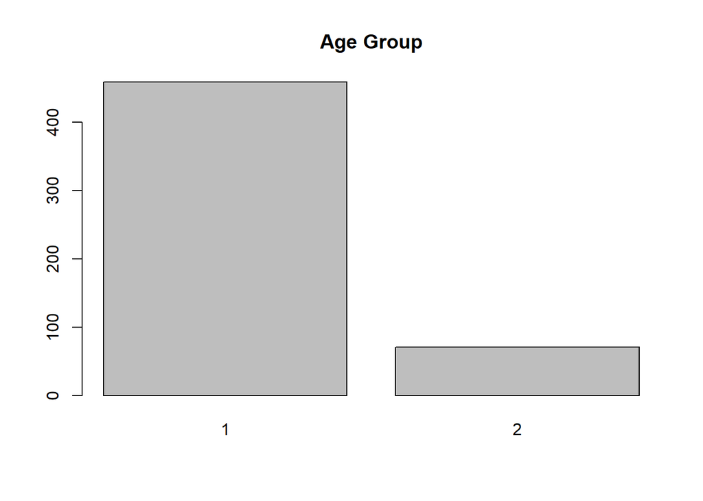

```r
# barplot(table()): it expects the frequencies, not the raw data
age_group_barplot <- barplot(table(rheum_arth_tibble$AgeGp))
title("Age Group")
```

**Converting the x-axis to a factor before plotting**

- If the variable is not already a factor, convert it to a factor variable before plotting, so the axis has appropriate labels
- Level 1 = 40 to 70 years old (“control”)
- Level 2 = 75 and older (“elderly”)

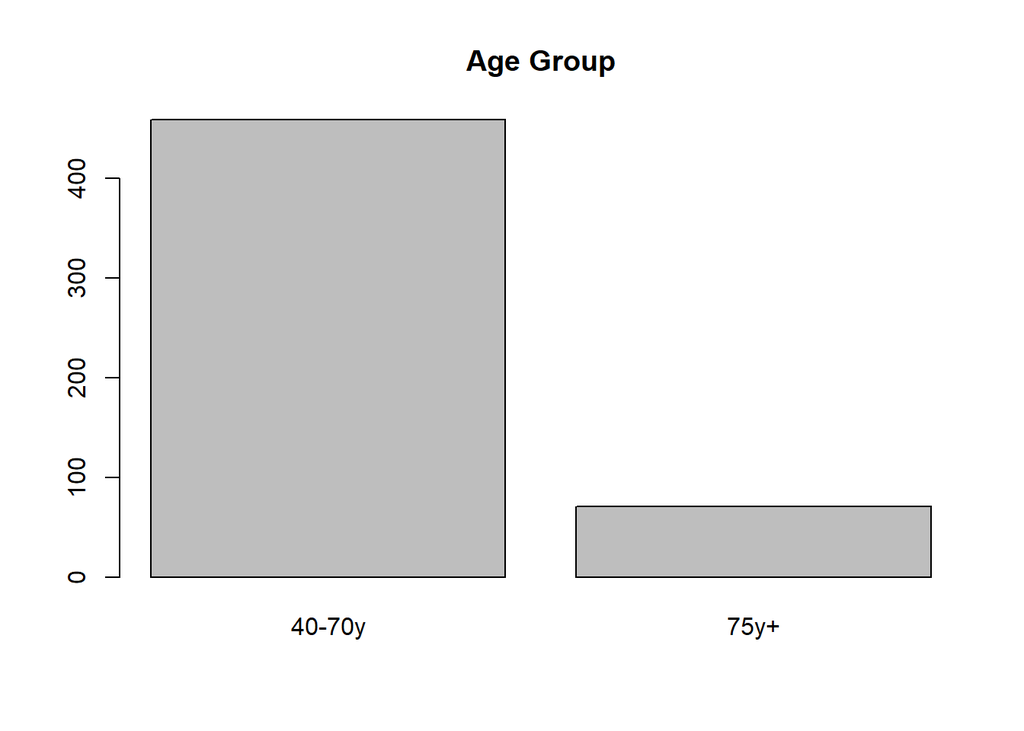

```r
# Bar chart for categorical variables
rheum_arth_tibble$AgeGp = factor(rheum_arth_tibble$AgeGp,
                                 levels = 1:2,
                                 labels = c("40-70y",
                                 "75y+"))

age_group_barplot_corr <- barplot(table(rheum_arth_tibble$AgeGp))
title("Age Group")
```

**Continuous variable - Histogram, boxplot**

[figure not shown]

```r
# Histogram for a continuous variable
yrs_drom_dx_hist <- hist(rheum_arth_tibble$Yrs_From_Dx)
title("Years since diagnosis at the time of the study")
```

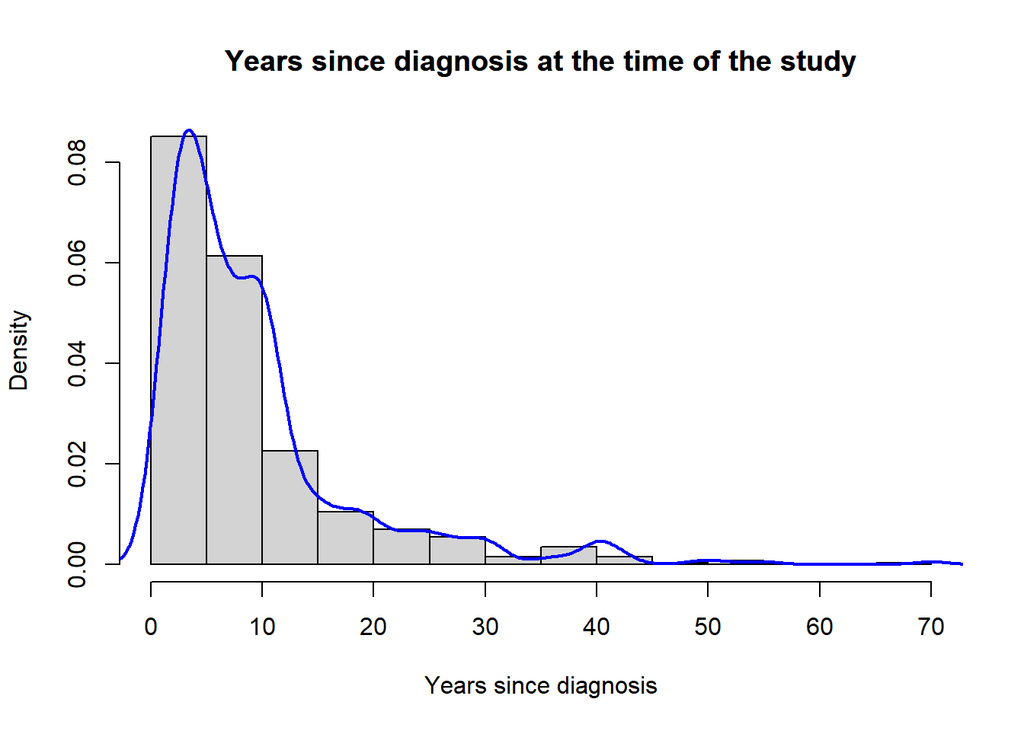

```r
# Density plot (histogram + density curve overlaid)
yrs_drom_dx_density <- hist(rheum_arth_tibble$Yrs_From_Dx, freq = FALSE,
     main = "Years since diagnosis at the time of the study",
     xlab = "Years since diagnosis")
lines(density(rheum_arth_tibble$Yrs_From_Dx, na.rm = TRUE), col = "blue", lwd = 2)
title("Years since diagnosis at the time of the study")
```

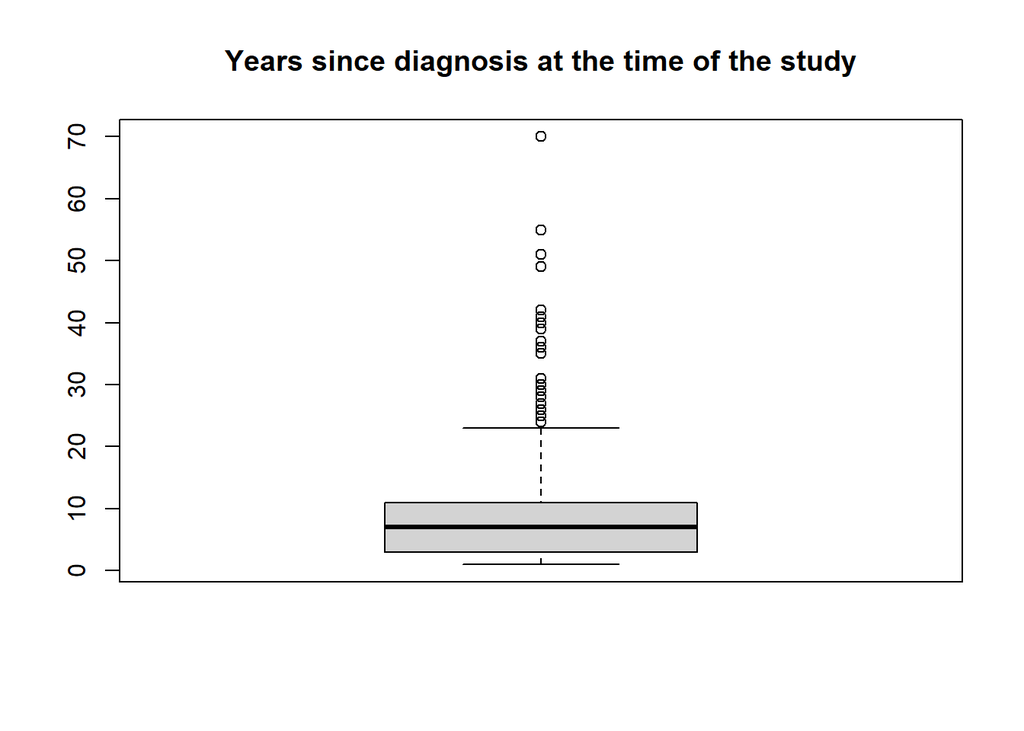

```r
# Boxplot for a continuous variable
yrs_drom_dx_boxplot <- boxplot(rheum_arth_tibble$Yrs_From_Dx)
title("Years since diagnosis at the time of the study")
```

**Pros and cons of tabular summaries**

- Advantage: see the extent of missing data
- Disdvantage: not easy to see the overall distribution of the data
- Use both tabular (data anomalies) and graphical (variable distribution) summaries

## Tidyverse - Summarizing the data (see also above)

**Use of the “pipe” operator %>%**

- It strings together functions (commands) operating on the same dataset
- When using %>%, do not name the dataset in every command
- The dataset appears only at the beginning of the pipe
- Later examples will demonstrate the use of multiple commands, strung together by multiple pipe operators

**Numbers of rows and columns in the dataset: enter the name of the tibble**

- Dimensions (number of observations × number of variables)
- Name of each variable
- Type of each variable
- First few rows, like head()

```r
rheum_arth_tibble_2 <- as_tibble(RheumArth_Tx_AgeComparisons)
rheum_arth_tibble_2
```

```
## # A tibble: 530 × 14
##       ID   Age AgeGp   Sex Yrs_From_Dx  CDAI CDAI_YN DAS_28 DAS28_YN
##    <int> <int> <int> <int>       <int> <dbl>   <int>  <dbl>    <int>
##  1     1    85     2     0          27  NA         1     NA        1
##  2     2    86     2     0          27  23         2     NA        1
##  3     3    83     2     0          10  14.5       2     NA        1
##  4     4    83     2     0           9  NA         1     NA        1
##  5     5    85     2     0          NA  NA         1     NA        1
##  6     6    79     2     1          NA  NA         1     NA        1
##  7     7    90     2     0          51  NA         1     NA        1
##  8     8    90     2     0          11  40         2     NA        1
##  9     9    87     2     0          36   6         2     NA        1
## 10    10    82     2     0           4  NA         1     NA        1
## # ℹ 520 more rows
## # ℹ 5 more variables: Steroids_GT_5 <int>, DMARDs <int>, Biologics <int>,
## #   sDMARDS <int>, OsteopScreen <int>
```

```r
# Check the name of each variable
names(rheum_arth_tibble_2)
```

```
##  [1] "ID"            "Age"           "AgeGp"         "Sex"
##  [5] "Yrs_From_Dx"   "CDAI"          "CDAI_YN"       "DAS_28"
##  [9] "DAS28_YN"      "Steroids_GT_5" "DMARDs"        "Biologics"
## [13] "sDMARDS"       "OsteopScreen"
```

```r
# Check the type of each variable (list-column, nested data, etc.)
str(rheum_arth_tibble_2)
```

```
## tibble [530 × 14] (S3: tbl_df/tbl/data.frame)
##  $ ID           : int [1:530] 1 2 3 4 5 6 7 8 9 10 ...
##  $ Age          : int [1:530] 85 86 83 83 85 79 90 90 87 82 ...
##  $ AgeGp        : int [1:530] 2 2 2 2 2 2 2 2 2 2 ...
##  $ Sex          : int [1:530] 0 0 0 0 0 1 0 0 0 0 ...
##  $ Yrs_From_Dx  : int [1:530] 27 27 10 9 NA NA 51 11 36 4 ...
##  $ CDAI         : num [1:530] NA 23 14.5 NA NA NA NA 40 6 NA ...
##  $ CDAI_YN      : int [1:530] 1 2 2 1 1 1 1 2 2 1 ...
##  $ DAS_28       : num [1:530] NA NA NA NA NA NA NA NA NA NA ...
##  $ DAS28_YN     : int [1:530] 1 1 1 1 1 1 1 1 1 1 ...
##  $ Steroids_GT_5: int [1:530] 0 1 1 1 0 0 0 1 0 0 ...
##  $ DMARDs       : int [1:530] 1 1 1 1 0 0 1 0 0 1 ...
##  $ Biologics    : int [1:530] 0 0 1 0 0 0 1 0 1 0 ...
##  $ sDMARDS      : int [1:530] 0 0 0 0 0 0 0 0 0 0 ...
##  $ OsteopScreen : int [1:530] 0 1 1 1 0 0 0 1 1 1 ...
```

```r
# Check the name and type of each variable (list-column, nested data, etc.)
glimpse(rheum_arth_tibble_2)
```

```
## Rows: 530
## Columns: 14
## $ ID            <int> 1, 2, 3, 4, 5, 6, 7, 8, 9, 10, 11, 12, 13, 14, 15, 16, 1…
## $ Age           <int> 85, 86, 83, 83, 85, 79, 90, 90, 87, 82, 77, 86, 84, 76, …
## $ AgeGp         <int> 2, 2, 2, 2, 2, 2, 2, 2, 2, 2, 2, 2, 2, 2, 2, 2, 2, 2, 2,…
## $ Sex           <int> 0, 0, 0, 0, 0, 1, 0, 0, 0, 0, 0, 0, 0, 0, 0, 0, 0, 0, 0,…
## $ Yrs_From_Dx   <int> 27, 27, 10, 9, NA, NA, 51, 11, 36, 4, 31, NA, 9, 10, 3, …
## $ CDAI          <dbl> NA, 23.0, 14.5, NA, NA, NA, NA, 40.0, 6.0, NA, 0.0, NA, …
## $ CDAI_YN       <int> 1, 2, 2, 1, 1, 1, 1, 2, 2, 1, 2, 1, 1, 1, 1, 1, 1, 1, 1,…
## $ DAS_28        <dbl> NA, NA, NA, NA, NA, NA, NA, NA, NA, NA, NA, NA, NA, 2.44…
## $ DAS28_YN      <int> 1, 1, 1, 1, 1, 1, 1, 1, 1, 1, 1, 1, 1, 2, 1, 1, 1, 1, 1,…
## $ Steroids_GT_5 <int> 0, 1, 1, 1, 0, 0, 0, 1, 0, 0, 1, 0, 0, 0, 0, 0, 0, 0, 0,…
## $ DMARDs        <int> 1, 1, 1, 1, 0, 0, 1, 0, 0, 1, 1, 0, 1, 1, 0, 0, 0, 0, 1,…
## $ Biologics     <int> 0, 0, 1, 0, 0, 0, 1, 0, 1, 0, 0, 0, 0, 1, 0, 0, 0, 0, 0,…
## $ sDMARDS       <int> 0, 0, 0, 0, 0, 0, 0, 0, 0, 0, 0, 0, 0, 0, 0, 0, 0, 0, 0,…
## $ OsteopScreen  <int> 0, 1, 1, 1, 0, 0, 0, 1, 1, 1, 1, 1, 1, 1, 1, 1, 1, 1, 1,…
```

### Tidyverse - Tabular inspection

- Get a quick overview of each variable in the dataset
- table(), R function: see all the possible values of a variable, the listing is horizontal (1 column for each unique combination)
- count(), Tidyverse: see all the possible values of a variable, the listing is vertical (1 row for each unique combination), the number of missing values are included by default
- mutate(): manipulate variables (not shown here)
- case_when(): replace values with NA if they meet a certain condition (not shown here)

### Tidyverse - Graphical inspection

- While base R uses a variety of functions like plot(), barplot(), hist()
- Data visualization in tidyverse is generally done using ggplot()
- ggplot() has a more complicated syntax than the base R plot functions
- But it brings together many different visualizations into one consistent syntax
- Start with a dataset name, then use the pipe operator %>%, then ggplot()
- aes() stands for “aesthetic”: which variables go on each axis, and if there is a grouping variable

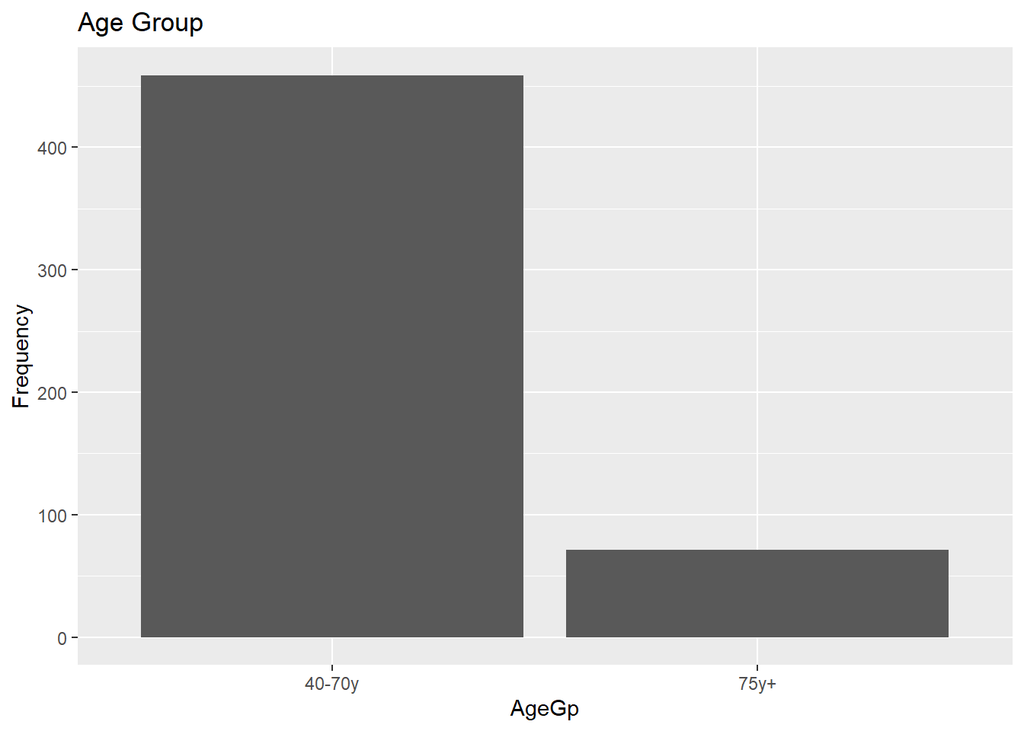

```r
# Bar chart for a categorical variable
# Convert AgeGp to a factor before plotting
rheum_arth_tibble_2 %>%
  mutate(AgeGp = factor(AgeGp,
                        levels = 1:2,
                        labels = c("40-70y",
                                   "75y+"))) %>%
  ggplot(aes(x = AgeGp)) +
  geom_bar() +
  labs(title = "Age Group", y = "Frequency")
```

```
## Warning: Removed 15 rows containing non-finite outside the scale range
## (`stat_bin()`).
```

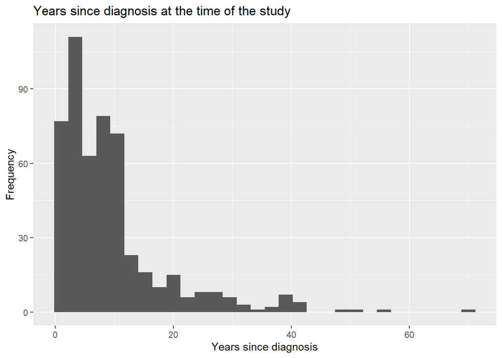

```r
# Histogram for a continuous variable
rheum_arth_tibble_2 %>%
  ggplot(aes(x = Yrs_From_Dx)) +
  geom_histogram() +
  labs(y = "Frequency", x = "Years since diagnosis") +
  ggtitle("Years since diagnosis at the time of the study")
```

**Some warnings when plotting a histogram**

- “Pick better value with binwidth”: how wide the bins are for the histogram
- Wider bins result in a smoother histogram
- Ignore it, or change the value as shown below

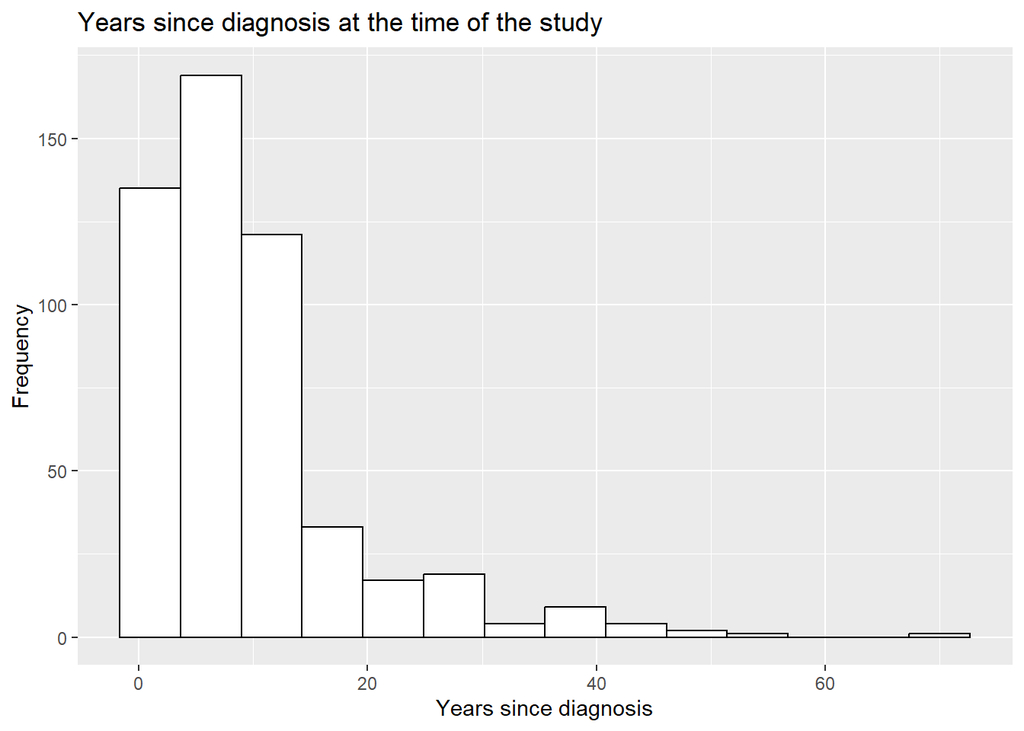

```r
# Histogram for a continuous variable
# Set bins, bar color, bar fill
rheum_arth_tibble_2 %>%
  ggplot(aes(x = Yrs_From_Dx)) +
  geom_histogram(bins = 14, color="black", fill="white") +
  labs(y = "Frequency", x = "Years since diagnosis") +
  ggtitle("Years since diagnosis at the time of the study")
```

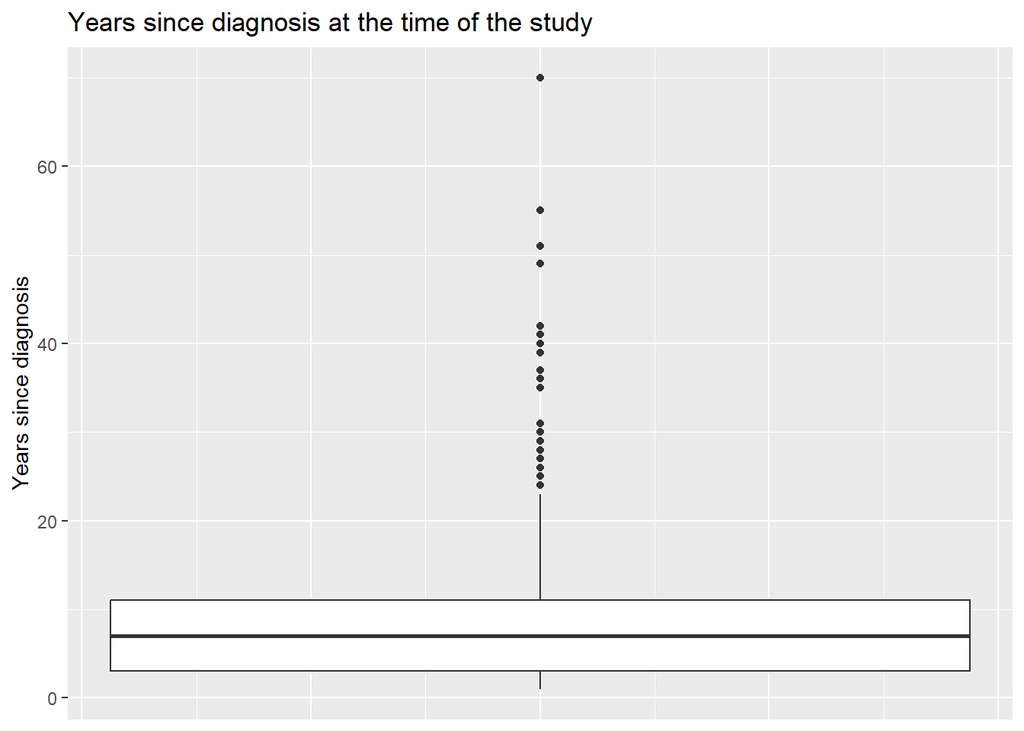

```r
# Boxplot for a continuous variable
# Vertical boxplot: use y in aes and labs, x in theme
rheum_arth_tibble_2 %>%
  ggplot(aes(y = Yrs_From_Dx)) +
  geom_boxplot() +

  # Without these theme statements,
  # there will be a meaningless x-axis
  theme(axis.text.x  = element_blank(),
        axis.ticks.x = element_blank()) +
  labs(y = "Years since diagnosis") +
  ggtitle("Years since diagnosis at the time of the study")
```

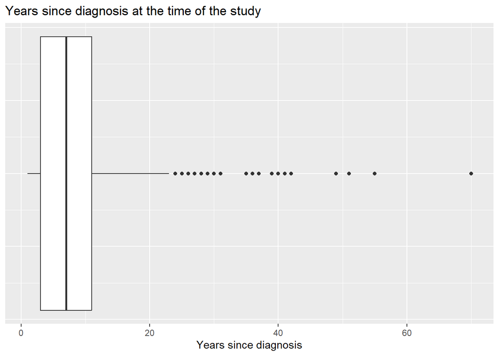

```r
# Boxplot for a continuous variable
# Horizontal boxplot: use x in aes and labs, y in theme
rheum_arth_tibble_2 %>%
  ggplot(aes(x = Yrs_From_Dx)) +
  geom_boxplot() +

  # Without these theme statements,
  # there will be a meaningless y-axis
  theme(axis.text.y  = element_blank(),
        axis.ticks.y = element_blank()) +
  labs(x = "Years since diagnosis") +
  ggtitle("Years since diagnosis at the time of the study")
```